[figure not shown]

# Introduction to the CHETAH package

Jurrian de Kanter

2018-11-07

# 1 Introduction

**CHETAH is a package for cell type identification of single-cell RNA-sequencing (scRNA-seq) data.**  
Cell types are assigned by correlating the input data to a reference in a hierarchical manner. CHETAH is built to work with scRNA-seq references, but will also work with RNA-seq or micro-array reference datasets.

CHETAH can be downloaded and installed from Bitbucket.

Note that `devtools::install_bitbucket` does not always install dependencies:  
‘bioDist’, ‘ggplot2’, ‘gplots’, ‘dendextend’, ‘cowplot’ and ‘corrplot’ are needed for installation

```r
devtools::install_bitbucket("jdekanter/Immune_class/CHETAH")

# --- Install dependencies, if this did not happen automatically
source("https://bioconductor.org/biocLite.R")
biocLite('bioDist', 'ggplot2', 'gplots', 'cowplot', 'dendextend', 'corrplot')

# Load the package
library(CHETAH)
```

**A comprehensive reference dataset for tumor data can be downloaded:** [here](https://figshare.com/s/aaf026376912366f81b6). This reference can be used for all (tumor) input datasets.

## 1.1 Types of classifications

CHETAH constructs a classification tree by hierarchically clustering the reference data. The classification is guided by this tree. In each node of the tree, cells are either assigned to the right, or the left branch. A confidence score is calculated for each of these assignments. When the confidence score for an assignment is lower than the threshold (default = 0.1), the classification for that cells stops in that node.  
This results in two types of classifications:

- **Final types**: Cells that are classified to one of the leaf nodes of the tree (i.e. a cell type of the reference).
- **Intermediate types**: Cells that had a confidence score lower than the threshold in a certain node are assigned to that intermediate node of the tree. This happens when a cell has approximately the same similarity to the right and the left branch of that node.

# 2 Running CHETAH

## 2.1 The function

Running CHETAH requires only one function: `CHETAHclassifier`.

## 2.2 Input variables

CHETAH needs two inputs: **reference** and **input** expression matrices.

All parameter names of `CHETAHclassifier` are displayed as `code`.

An expression matrix is a matrix, Matrix or data frame with samples/cells in the columns and genes in the rows.

The same gene id type (e.g. gene symbols, ensemble ids, etc) must be used in the input and reference.

1. `input`
   - An expression matrix or data frame with the input cells
2. A reference, one of:
   1. An expression matrix of reference cells (`ref_cells`) and a named character vector (`ref_types`) of the cell types of `ref_cells`. The names of `ref_types` must correspond with the column names of `ref_cells`.

   ```r
   str(ref_oneMatrix) ## ref_cells
   ```

   ```
   #>  num [1:7943, 1:180] 0 0 0 0 0.148 ...
   #>  - attr(*, "dimnames")=List of 2
   #>   ..$ : chr [1:7943] "ELMO2" "PNMA1" "MMP2" "TMEM216" ...
   #>   ..$ : chr [1:180] "HNSCC22_P2_pri_A03_S195_comb" "HN28_P3P4_G11_S83_comb" "HN28_P5_G12_S276_comb" "HNSCC25_P4_B12_S216_comb" ...
   ```

   ```r
   str(ref_types) ## ref_types
   ```

   ```
   #>  Named chr [1:180] "Fibroblast" "Fibroblast" "Fibroblast" "Fibroblast" ...
   #>  - attr(*, "names")= chr [1:180] "HNSCC22_P2_pri_A03_S195_comb" "HN28_P3P4_G11_S83_comb" "HN28_P5_G12_S276_comb" "HNSCC25_P4_B12_S216_comb" ...
   ```

   ```r
   all.equal(names(ref_types), colnames(ref_oneMatrix))
   ```

   ```
   #> [1] TRUE
   ```

   2. A list of scRNA-seq expression matrices (`ref_cells`). Each object must hold a matrix of cells of one cell type and must be named with that cell type, e.g: a list of 3 objects named “B”, “NK” and “T”, holding an expression matrix of exclusively B, NK, and T cells respectively.

   ```r
   ls.str(ref_listOfMatrices) ## ref_cells
   ```

   ```
   #> B cell :  num [1:7943, 1:20] 0 0 0 0 0.195 ...
   #> CD4 T cell :  num [1:7943, 1:20] 0 0 0 0 0.533 ...
   #> CD8 T cell :  num [1:7943, 1:20] 4.1738 0 0 0 0.0909 ...
   #> Dendritic :  num [1:7943, 1:20] 0 0 0 0 0.124 ...
   #> Endothelial :  num [1:7943, 1:20] 0 0 1.53 0 1.99 ...
   #> Fibroblast :  num [1:7943, 1:20] 0 0 0 0 0.148 ...
   #> Macrophange :  num [1:7943, 1:20] 3.776 0 0.123 0 0 ...
   #> Mast :  num [1:7943, 1:20] 0 0 0 0 0.409 ...
   #> reg. T cell :  num [1:7943, 1:20] 0 0 0 0 0.562 ...
   ```

   3. In the case of bulk RNA-seq or micro-array reference data (when only one expression profile per cell type is available) a expression matrix must be provided in `ref_profiles` with the cell types as the column names.

   ```r
   str(ref_bulkProfiles) ## ref_profiles
   ```

   ```
   #>  num [1:7943, 1:9] 0.751 1.1 2.357 0.437 0.603 ...
   #>  - attr(*, "dimnames")=List of 2
   #>   ..$ : chr [1:7943] "ELMO2" "PNMA1" "MMP2" "TMEM216" ...
   #>   ..$ : chr [1:9] "Fibroblast" "B cell" "Macrophange" "Endothelial" ...
   ```

### 2.2.1 Example data

In this vignette, the following example data from the CHETAH package are used:

More information and complete references for each object can be found in it’s help page, e.g. `?reference_hn`

- `reference_hn`: A list of expression matrices of data from Puram et al. (2017) Cancer Cell.

  ```r
  ls.str(reference_hn)
  ```

  ```
  #> B cell :  num [1:7943, 1:20] 0 0 0 0 0.195 ...
  #> CD4 T cell :  num [1:7943, 1:20] 0 0 0 0 0.533 ...
  #> CD8 T cell :  num [1:7943, 1:20] 4.1738 0 0 0 0.0909 ...
  #> Dendritic :  num [1:7943, 1:20] 0 0 0 0 0.124 ...
  #> Endothelial :  num [1:7943, 1:20] 0 0 1.53 0 1.99 ...
  #> Fibroblast :  num [1:7943, 1:20] 0 0 0 0 0.148 ...
  #> Macrophange :  num [1:7943, 1:20] 3.776 0 0.123 0 0 ...
  #> Mast :  num [1:7943, 1:20] 0 0 0 0 0.409 ...
  #> reg. T cell :  num [1:7943, 1:20] 0 0 0 0 0.562 ...
  ```

- `data_mel`: An expression matrix of data from two tumors from Tirosh et al. (2016) Science.

  ```r
  str(data_mel)
  ```

  ```
  #> Formal class 'dgCMatrix' [package "Matrix"] with 6 slots
  #>   ..@ i       : int [1:523911] 4 6 8 14 15 19 23 28 30 32 ...
  #>   ..@ p       : int [1:151] 0 2948 5452 8201 10304 13837 18707 21530 24002 28775 ...
  #>   ..@ Dim     : int [1:2] 7943 150
  #>   ..@ Dimnames:List of 2
  #>   .. ..$ : chr [1:7943] "ELMO2" "PNMA1" "MMP2" "TMEM216" ...
  #>   .. ..$ : chr [1:150] "cy53.1.CD45.pos.2.A06.S966.comb" "cy80.CD45.neg.C05.S893.comb" "cy80.Cd45.pos.PD1.pos.S110.E02.S110.comb" "cy80.CD45.pos.PD1.pos.F10.S166.comb" ...
  #>   ..@ x       : num [1:523911] 2.13 5.693 5.435 0.309 2.781 ...
  #>   ..@ factors : list()
  ```

- `tsne_mel`: The coordinates resulting from running t-SNE<sup>1</sup> on `data_mel`

  ```r
  str(tsne_mel)
  ```

  ```
  #>  num [1:150, 1:2] 4.503 -4.003 0.473 3.22 -0.335 ...
  #>  - attr(*, "dimnames")=List of 2
  #>   ..$ : chr [1:150] "cy53.1.CD45.pos.2.A06.S966.comb" "cy80.CD45.neg.C05.S893.comb" "cy80.Cd45.pos.PD1.pos.S110.E02.S110.comb" "cy80.CD45.pos.PD1.pos.F10.S166.comb" ...
  #>   ..$ : chr [1:2] "tSNE_1" "tSNE_2"
  ```

## 2.3 The reference

### 2.3.1 Normalization

CHETAH does not require normalized input data, but **the reference data has to be normalized beforehand**. The reference data that is used in this vignette is already normalized. However, for sake of the example, let’s say it is not normalized, then normalization could be performed as follows:

```r
reference <- reference_hn
reference <- lapply(reference, function(matrix) apply(matrix, 2, function(column) log2((column/sum(column) * 100000) + 1)))
```

### 2.3.2 Important characteristics of a Reference

CHETAH can use any scRNA-seq reference, but the reference greatly influences the classification.  
The following general rules apply for choosing and creating a reference:

- Better results can be achieved by using a reference and an input dataset that are from the same biological type, or at least consist of cells that are in the same cell state. E.g. for a dataset of PBMCs a bone marrow reference dataset could be used, but as these cells are more naive or precursors, this might negatively influence the classification. In this case, another PBMC dataset would work optimally.
- The annotation of the reference directly influences the classification. The more accurate the cell type labels, the better the classification.
- CHETAH works better with less sparse reference data.
- The sparser the reference data, the more reference cells are needed to create a reliable, robust reference profile. For high coverage Smart-Seq2<sup>2</sup> data, as little as 20-30 cells are needed per cell type. For sparser 10X Genomics data, 100+ cells gives optimal results.

## 2.4 Calling the function

CHETAH is run as follows:

```
#> Preparing data....
#> Running analysis...
```

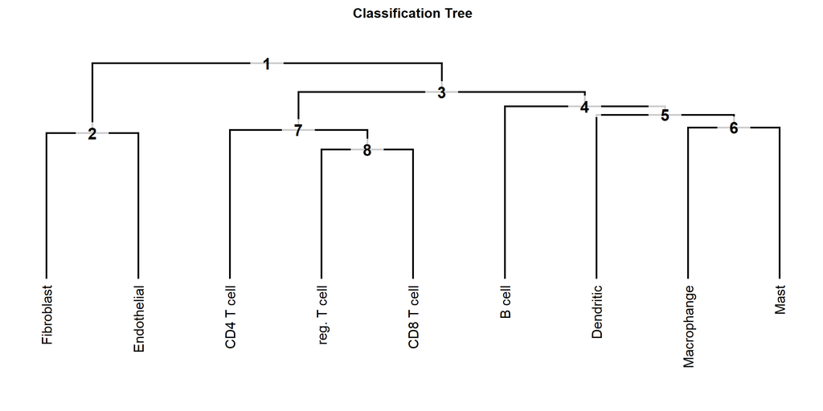

```r
reference <- reference_hn
input <- data_mel
chetah <- CHETAHclassifier(input = input, ref_cells = reference, plot.tree = TRUE)
```

## 2.5 Output

The output of CHETAH is a list. See `?CHETAHclassifier` for more information.  
The most important object in this list is `chetah$classification`. This is a named character of the classification. This vector can be used for further analysis. For example, it can be directly integrated into a Seurat<sup>3</sup> object as metadata.

# 3 Visualize outcome

## 3.1 Standard plots

CHETAH comes with different functions to visualize it’s output, but the most important one is `PlotCHETAH`.  
This function colors either the **final types** or the **intermediate types**.

Provide your own coordinates for the cells, e.g. from t-SNE, in the `coor` variable. `coor` must be a matrix or data frame of coordinates with the two dimensions in the columns and the cells in the rows.

To plot the **final types**:

```r
tsne <- tsne_mel
str(tsne)
```

```
#>  num [1:150, 1:2] 4.503 -4.003 0.473 3.22 -0.335 ...
#>  - attr(*, "dimnames")=List of 2
#>   ..$ : chr [1:150] "cy53.1.CD45.pos.2.A06.S966.comb" "cy80.CD45.neg.C05.S893.comb" "cy80.Cd45.pos.PD1.pos.S110.E02.S110.comb" "cy80.CD45.pos.PD1.pos.F10.S166.comb" ...
#>   ..$ : chr [1:2] "tSNE_1" "tSNE_2"
```

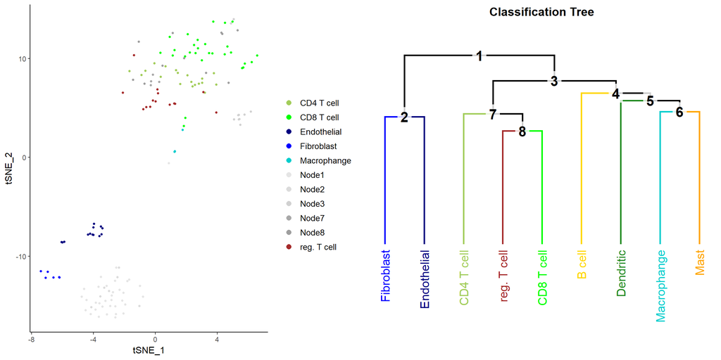

```r
PlotCHETAH(chetah = chetah, coor = tsne)
```

Conversely, to plot the **intermediate types**:

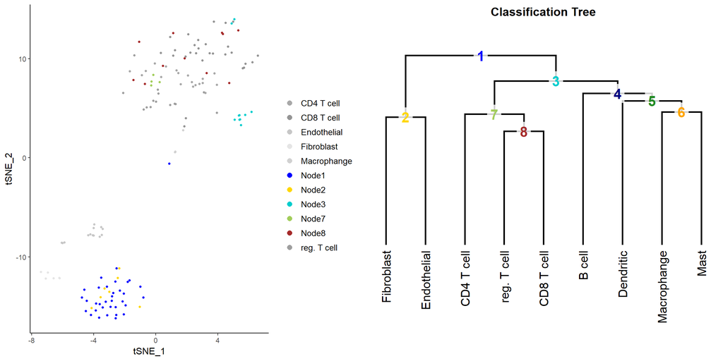

```r
PlotCHETAH(chetah = chetah, coor = tsne, interm = TRUE)
```

## 3.2 `CHETAHshiny`

The classification of CHETAH and other outputs like profile and confidence scores can be manually assessed in R, but CHETAH also comes with an intuitive shiny application that allows for easy and interactive visual analysis of the classification.

The shiny implementation needs three things:

- A chetah object (/list)
- The 2D coordinates (e.g. from t-SNE) of the input cells
- The count matrix of the original data

When the data is large (more than 2000 cells), it is advised to use a sparse Matrix for the cout data

To run CHETAH on the example data:

The following command will open the shiny application as a web page in your default web browser

```r
CHETAHshiny(chetah = chetah, coor = tsne, counts = input)
```

See the help page tab in the application for an explanation of each plot

# 4 Additional functionality

## 4.1 Changing classification

CHETAH calculates a confidence score for each assignment of an input cell to one of the branches of a node.  
The confidence score:

- can have a value between 0 and 2
- will most frequently lie between 0 and 1
- 0 represents no confidence for a assignment, 1 high confidence.

**The default confidence threshold of CHETAH is 0.1.**  
This means that whenever a cell is assigned to a branch and the confidence of that assignment is lower than 0.1, the classification will stop in that node.

**The confidence threshold can be adjusted in order to classify more or fewer cells to a final type:**

- Using a confidence threshold of 0 will classify all input cells to a final type. Be aware that this classification can be noisy and can contain incorrect classifications.
- Using a threshold of 0.2, 0.3, 0.4, etc, will classify a decreasing number of cells to a final type, with the remaining cells having a increasingly high confidence throughout all nodes in the tree.

For example, to classify all cells:

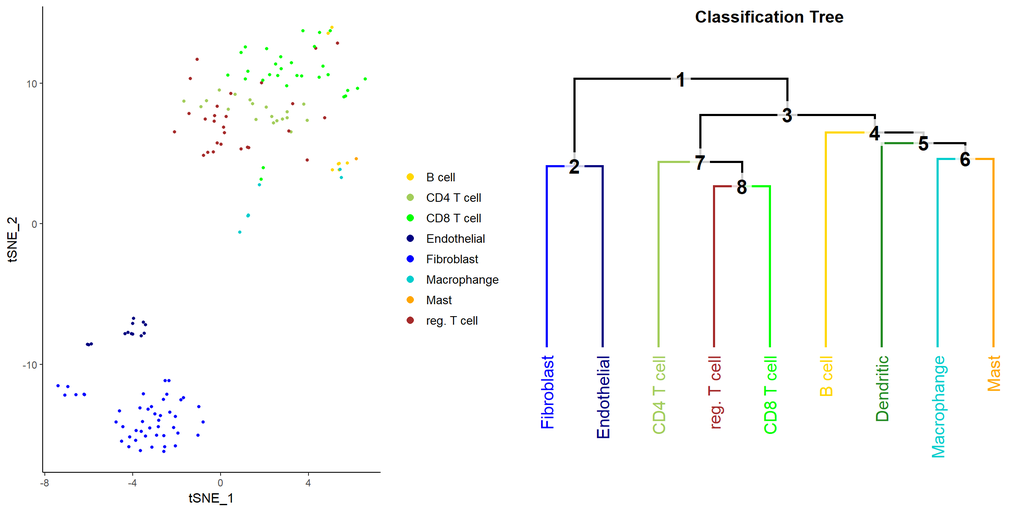

```r
chetah$classification <- Classify(chetah, 0)
PlotCHETAH(chetah = chetah, coor = tsne)
```

Conversely, to only classify cells with very high confidence:

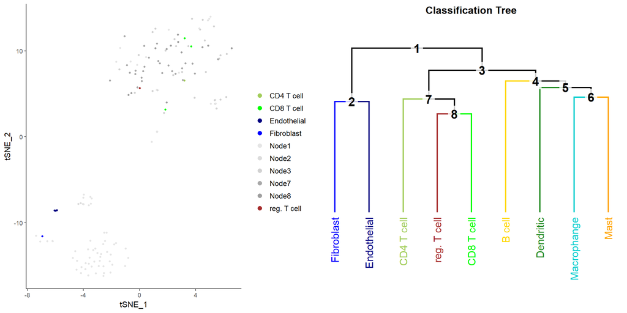

```r
chetah$classification <- Classify(chetah, 0.8)
PlotCHETAH(chetah = chetah, coor = tsne)
```

## 4.2 Reference quality control

The performance of CHETAH is heavily dependent on the quality of the reference.  
The quality of the reference is affected by:

1. the sparseness and quality of the scRNA-seq data
2. the accuracy of the cell type labels

CHETAH is also influenced by comparability of the reference cell types. If two cell types in the reference are differentiated by only a few genes that are differentially expressed, then CHETAH will not always be able to distinguish them.

To see how well CHETAH can distinguish between the cell types in a reference,  
`CorrelateReference` and `ClassifyReference` can be run.

### 4.2.1 CorrelateReference

`CorrelateReference` is a function that, for every combination of two cell types, finds the genes with the highest fold-change between the two and uses these to correlate them to each other. If the reference is good, all types will correlate poorly or even better, will anti-correlate.

```r
CorrelateReference(ref_cells = reference)
```

```
#> Running... this may take a couple of minutes
```

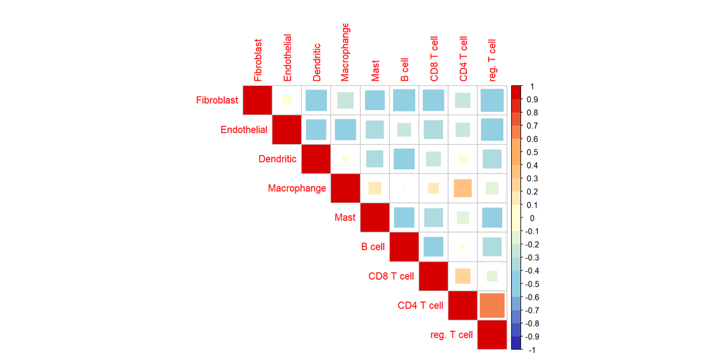

In this case, most cell types will be distinguishable: many types don’t correlate, or anti-correlate. However, some types are quire similar. Regulatory and CD4 T cells, or CD4 and CD8 T cells, might be hard to distinguish in the input data.

### 4.2.2 ClassifyReference

Another check to see whether CHETAH can distinguish between the cell types in the reference is `ClassifyReference`. This function uses the reference to classify the reference itself. If CHETAH works well with the reference, there should be almost no mix-ups in the classification, i.e. all cells of type A should be classified to type A.

```r
ClassifyReference(ref_cells = reference)
```

```
#> Preparing data....
#> Running analysis...
```

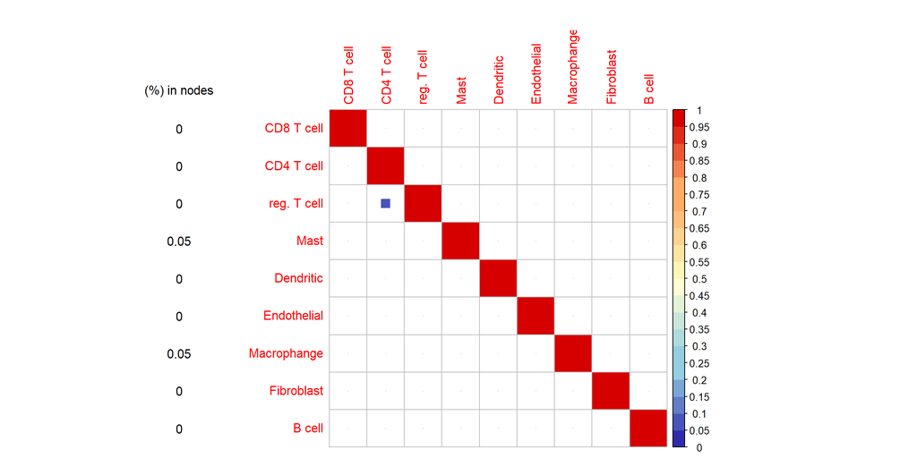

In this reference, there is never more than 10% mix-up between two cell types. In addition, a low percentage of cells is classified as an intermediate type. Most mix-ups occur between subtypes of T cells. In this case the user should be aware that these cell type labels have the highest chance to interchange.

<sup>1</sup> Van Der Maaten and Hinton (2008). Visualizing high-dimensional data using t-sne. *J Mach Learn Res*. 9: 2579-2605. doi: 10.1007/s10479-011-0841-3. <sup>2</sup> Picelli et al. (2013) Smart-seq2 for sensitive full-length transcriptome profiling in single cells. *Nat Methods*. 10(11): 1096-1100. doi: 10.1038/nmeth.2639. <sup>3</sup> Satija et al. (2015) Spatial reconstruction of single-cell gene expression data. *Nat Biotechnol*. 33(5):495-502. May 2015. doi: 10.1038/nbt.3192. More information at: https://satijalab.org/seurat/